# Coursera Practical Machine Learning with R Coursework

First we need to load the various libraries we will need for this assignment as well as to load in the training and test data from csv

```r
library(caret)
library(e1071)
library(rattle)
library(rpart)
# When reading in the training data, we want to replace empty strings with NA so that we can treat empty strings and NA the same way in the preprocessing steps
training.raw <- read.csv("pml-training.csv", na.strings = c("", "NA"))
testing.raw <- read.csv("pml-testing.csv")
```

Once we have done this, we will split the training data into 80/20 split of training and testing data, since we should only RUN our final model on the holdout set (20 rows) without exploring the data and without training our hyperparameters on it

```r
# Remove columns 1-6 which do not make sensible predictors in training set
training.first6columnsremoved <- training.raw[ -c(1:6) ]
# Remove columns containing NA in training set
training.first6columnsandnasremoved <- training.first6columnsremoved[, which(colMeans(!is.na(training.first6columnsremoved)) == 1)]
# Remove columns 1-6 which do not make sensible predictors in testing set
testing.first6columnsremoved <- testing.raw[ -c(1:6) ]
# Remove columns containing NA in testing set
testing.first6columnsandnasremoved <- testing.first6columnsremoved[, which(colMeans(!is.na(training.first6columnsremoved)) == 1)]
inTrain = createDataPartition(y = training.first6columnsandnasremoved$classe, p = 0.8, list=FALSE)
training = training.first6columnsandnasremoved[ inTrain,]
testing = training.first6columnsandnasremoved[-inTrain,]
set.seed(123)
#calculate the # of columns in the dataset, as we know that the last column is the target variable "classe"
col_classe_nb<-dim(training)[2]
#preprocess the data in order to get 95% of the variance
preProc <- preProcess(training[,-col_classe_nb],method="pca",thresh=0.95)
#Apply preProc object to training and testing and holdout dataset
training<-predict(preProc,training)
testing<-predict(preProc,testing)
holdout<-predict(preProc,testing.first6columnsandnasremoved)
preProc
```

```
## Created from 15699 samples and 53 variables
##
## Pre-processing:
##   - centered (53)
##   - ignored (0)
##   - principal component signal extraction (53)
##   - scaled (53)
##
## PCA needed 25 components to capture 95 percent of the variance
```

First we will try a decision tree model using rpart and we can plot it using rattle

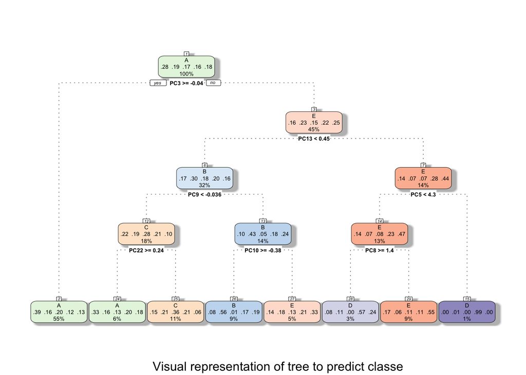

```r
set.seed(123)
fitRpart <- rpart(classe ~ ., data=training, method="class")
fancyRpartPlot(fitRpart, caption = "Visual representation of tree to predict classe")
```

Now we will estimate the out of sample accuracy for the tree model

```r
pred.rpart <- predict(fitRpart, testing, type="class")
acc.rpart <- confusionMatrix(table(factor(pred.rpart), factor(testing$classe)))$overall[1]
print(paste0("Out of sample estimated accuracy on rpart is ", acc.rpart))
```

```
## [1] "Out of sample estimated accuracy on rpart is 0.419067040530206"
```

Next we will try a random forest model using 5 fold cross-validation, which based on having seen data scientists that I work with using AutoML, usually seems to come out near or at the top of the model scoring leaderboard (along with gradient boosted trees) I chose 75 trees based on experimentation and a compromise between model accuracy and training time needed

```r
set.seed(123)
train.control <- trainControl(method = "cv", number = 5)
fitRf <- train(classe ~ ., data=training, method="rf", ntree=75, trControl=train.control)
pred.rf <- predict(fitRf, testing)
acc.rf <- confusionMatrix(table(factor(pred.rf), factor(testing$classe)))$overall[1]
print(paste0("Out of sample estimated accuracy on rf is ", acc.rf))
```

```
## [1] "Out of sample estimated accuracy on rf is 0.979607443283202"
```

Next we will try a gradient boosted model using 5 fold cross-validation, which based on having seen data scientists that I work with using AutoML, usually seems to come out near or at the top of the model scoring leaderboard (along with random forest)

```r
set.seed(123)
fitGbm <- train(classe ~ ., data=training, method="gbm", trControl=train.control, verbose = FALSE)
pred.gbm <- predict(fitGbm, testing)
acc.gbm <- confusionMatrix(table(factor(pred.gbm), factor(testing$classe)))$overall[1]
print(paste0("Out of sample estimated accuracy on gbm is ", acc.gbm))
```

```
## [1] "Out of sample estimated accuracy on gbm is 0.820545500892174"
```

The highest performing model based on experimentation was the random forest model (97%+ accuracy), so we will choose this as our final model and apply it on the 20 rows that we have in the holdout set.

```r
finalpredictions <- predict(fitRf, holdout)
print(finalpredictions)
```

```
##  [1] B A B A A E D B A A B C B A E E A B B B
## Levels: A B C D E
```